# Introduction to AirMonitor

Mazama Science

2025-05-16

## Installation

Install from CRAN with:

`install.packages('AirMonitor')`

Install the latest version from GitHub with:

`devtools::install_github('mazamascience/AirMonitor')`

## Available data

The USFS AirFire group regularly processes monitoring data in support of their various operational tools. Pre-processed, harmonized and QC’ed data files can be loaded with the following functions:

- `~_load()` – load data based on a start- and end-time
- `~loadAnnual()` – load a year’s worth of data
- `~loadDaily()` – load the most recent 45 days of data (updated once per day)
- `~loadLatest()` – load the most recent 10 days of data (updated every hour)

Data archives go back to 2014 or earlier depending on the data source.

## Recipes

We encourage people to embrace “recipe” style coding as enabled by **dplyr** and related packages. The special `%>%` operator uses the output of one function as the first argument of the next function, thus allowing for easy “chaining” of results to create a step-by-step recipe.

With only a few exceptions, all the `monitor_` functions accept a *mts_monitor* object as their first argument and generate a *mts_monitor* object as a result so they can be chained together.

## A first example

Let’s say we are interested in the impact of smoke from the 2018 Camp Fire in the Sacramento area.

We would begin by creating a `Camp_Fire` object that has all the monitors in California for the period of interest. The recipe for creating `Camp_Fire` has four steps: 1) load annual data; 2) filter for monitors in California; 3) restrict the date range to Camp Fire dates; 4) remove any monitors with no valid data in this range.

```
# create the Camp_Fire 'mts_monitor' object
Camp_Fire <-

  # 1) load annual data
  monitor_loadAnnual(2018) %>%

  # 2) filter for California
  monitor_filter(stateCode == 'CA') %>%

  # 3) restrict date range
  monitor_filterDate(
    startdate = 20181108,
    enddate = 20181123,
    timezone = "America/Los_Angeles"
  ) %>%

  # 4) remove monitors with no valid data
  monitor_dropEmpty()
```

We can use the `monitor_leaflet()` function to display these monitors (colored by maximum PM2.5 value) in an interactive map. This map allows us to zoom in and click on the monitor in downtown Sacramento to get it’s `deviceDeploymentID` – “127e996697f9731c_840060670010”.

```r
monitor_leaflet(Camp_Fire)
```

[interactive chart not shown]

We can use this `deviceDeploymentID` to create a *mts_monitor* object for this single monitor and take a look at a time series plot. Day-night shading and AQI decorations create a publication-ready plot:

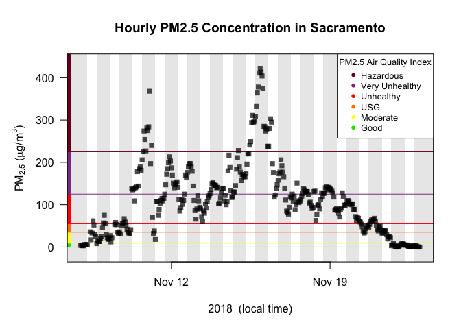

```r
# create single-monitor Sacramento
Sacramento <-

  # 1) start with Camp_Fire
  Camp_Fire %>%

  # 2) select a specific device-deployment
  monitor_select("127e996697f9731c_840060670010")

# review timeseries plot
Sacramento %>%
  monitor_timeseriesPlot(
    shadedNight = TRUE,
    addAQI = TRUE,
    main = "Hourly PM2.5 Concentration in Sacramento"
  )

# add the AQI legend
addAQILegend(cex = 0.8)
```

Next, we can use this specific location to create a *mts_monitor* object containing all monitors within 50 kilometers (31 miles) of Sacramento.

```r
Sacramento_area <-

  # 1) start with Camp_Fire
  Camp_Fire %>%

  # 2) find all monitors within 50km of Sacramento
  monitor_filterByDistance(
    longitude = Sacramento$meta$longitude,
    latitude = Sacramento$meta$latitude,
    radius = 50000
  )

monitor_leaflet(Sacramento_area)
```

[interactive chart not shown]

We can use the same `monitor_timeseriesPlot()` function to display the hourly data for *all* the monitors in the Sacramento area in a single plot. This gives a sense of the range of values within the area at any given hour.

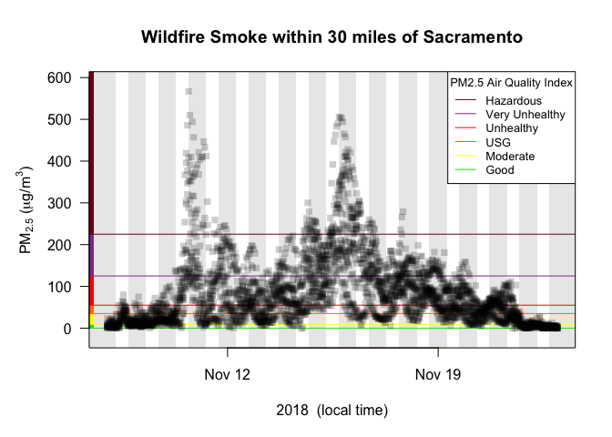

```r
Sacramento_area %>%
  monitor_timeseriesPlot(
    shadedNight = TRUE,
    addAQI = TRUE,
    main = "Wildfire Smoke within 30 miles of Sacramento"
  )

addAQILegend(lwd = 1, pch = NA, bg = "white", cex = 0.8)
```

Now we can average together all the monitors and create a local-time, daily average for the Sacramento area.

```r
# 1) start with Sacramento_area
Sacramento_area %>%

  # 2) average together all timeseries hour-by-hour
  monitor_collapse(
    deviceID = "Sacramento_area"
  ) %>%

  # 3) calculate the local-time daily average (default)
  monitor_dailyStatistic() %>%

  # 4) pull out the $data dataframe
  monitor_getData()
```

```
## # A tibble: 15 × 2
##    datetime            `9qce5hqsq9_Sacramento_area`
##    <dttm>                                     <dbl>
##  1 2018-11-08 00:00:00                        16.6
##  2 2018-11-09 00:00:00                        23.5
##  3 2018-11-10 00:00:00                       117.
##  4 2018-11-11 00:00:00                       106.
##  5 2018-11-12 00:00:00                        78.1
##  6 2018-11-13 00:00:00                        68.6
##  7 2018-11-14 00:00:00                       107.
##  8 2018-11-15 00:00:00                       192.
##  9 2018-11-16 00:00:00                       160.
## 10 2018-11-17 00:00:00                        98.0
## 11 2018-11-18 00:00:00                        94.7
## 12 2018-11-19 00:00:00                        68.2
## 13 2018-11-20 00:00:00                        44.5
## 14 2018-11-21 00:00:00                        32.9
## 15 2018-11-22 00:00:00                         5.01
```

Alternatively, we can plot the daily averages.

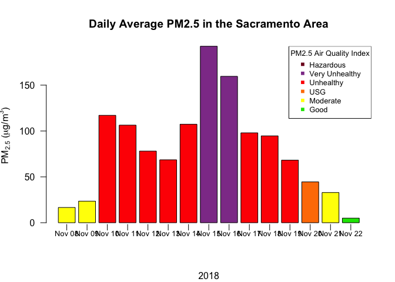

```r
# 1) start with Sacramento_area
Sacramento_area %>%

  # 2) average together all timeseries hour-by-hour
  monitor_collapse() %>%

  # 3) create daily barplot
  monitor_dailyBarplot(
    main = "Daily Average PM2.5 in the Sacramento Area"
  )

# add the AQI legend
addAQILegend(pch = 15, bg = "white", cex = 0.8)
```

Best of luck analyzing your local air quality data!